# Word Representation

Introduction to NLP — MSc. DH ENC-PSL

Noé Durandard (noe.durandard@psl.eu)

October 7, 2026

# 1 Recap

- NLP deals with **natural** (ambiguous, fluid, evolving, …) **language**
- The field has evolved toward **learning from data**…
- … which is not inherently objective but results from a *construction of truth*.

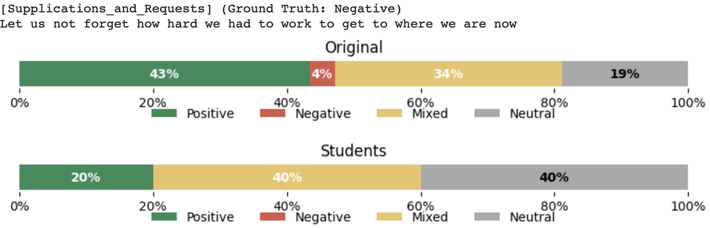

Sample Analysis from last week’s *Annotation Workshop*.

# 2 Tokenization & Representation

## 2.1 Motivation

### 2.1.1 The symbolic gap

- Computers do **not** process words, or concepts directly; they compute on **numbers, matrices, and vectors**.
- **Raw Text in Memory:** A continuous stream of Unicode bytes or ASCII characters.

### 2.1.2 Definition

**Tokenization**

the task of separating out or tokenizing words and word parts from running text. (Jurafsky and Martin 2026)

Process flow:

Raw text $\to$ `tokenize` $\to$ Token sequence $\to$ `vocabulary lookup` $\to$ Vocabulary IDs

### 2.1.3 Is it `token = word`?

$\to$ What is a *word*?

- `cat` (standard, unambiguous)
- `I'm` (one orthographically, two grammatically)
- `San Francisco` (two orthographically, one semantic entity)
- `C U` (abbreviation / chat speak)
- What about languages without whitespace separators?

The concept of a “word” is *ill-defined*, *context-bound*, and *language-dependent*.

Note: For simplicity, you may think of `token ≈ word`, but keep in mind that these notions differ in practice.

### 2.1.4 The universal first step

Regardless of historical era or model paradigm, **tokenization is the gateway to every NLP pipeline**:

**Traditional NLP Pipeline**

```
[ Raw Text ]
     │
     ▼
[ Tokenization ]
     │
     ▼
[ Stopwords removal [?] ]
     │
     ▼
[ ... ]
```

- Discrete rule-based or statistical features.

**Modern Neural Pipeline**

```
[ Raw Text ]
     │
     ▼
[ Subword Tokenizer ]
     │
     ▼
[ Token ID Sequence ]
     │
     ▼
[ Dense Vector Embeddings ]
```

- Continuous vector spaces & Transformers.

## 2.2 Tokenization Approaches

### 2.2.1 Tokenizer’s Desiderata

Raw text$\to$`tokenizer`$\to$discret **tokens** from **vocabulary** $\mathcal{V}$.

That vocabulary and mapping should be:

- **Expressive**
  - able to represent any given text (any language)
  - avoid missing elements and cleanly represent variants
- **Efficient**
  - not too large: large vocabulary $\Rightarrow$ bloated lookup tables, more parameters to store (/learn).
  - not too small: smaller vocabulary $\Rightarrow$ longer sequences, computationally expensive.

### 2.2.2 ‘Word’-Level & Pattern matching

Using regular expressions to isolate ‘words’ explicitly:

```python
import re
text = "The cat is on the mat, the dog isn't."
tokens = re.findall(r"\w+|[^\w\s]", text)
# Output: ['The', 'cat', 'is', 'on', 'the', 'mat', ',', 'the', 'dog', 'isn', "'", 't', '.']
```

Limitations: **Size Explosion**, **Out-Of-Vocabulary** (OOV) issues, rely on **whitespace delimiters** (what about other languages: Chinese, Japanese, Ancient Greek *scriptio continua*, etc.?)

**Regex as pre-tokenization**

Note that such approaches are still the foundation *pre*-tokenization step of modern tokenizers!

It is used to prevent from merging across punctuation and space boundaries (more shortly).

### 2.2.3 Character- & Byte-Level

Split text into raw individual characters or UTF-8 bytes:

```python
text = "the cat"
chars = list(text)
utfs = list(text.encode('utf-8'))
# chars: ['t', 'h', 'e', ' ', 'c', 'a', 't']
# utfs : [116, 104, 101, 32, 99, 97, 116]
```

**Pros**:

- Complete expressivity (any unicode string)
- Very small vocabulary: UTF-8 = 256 bytes

**Cons**:

- Inefficient: yield very long sequences
- Weak individual semantics

### 2.2.4 Subword-level

**Goal**: Find middle ground between **word-level** (rich semantics, high OOV risk, large vocabulary) and **character-level** (zero OOV, tiny vocabulary, long sequence length, poor semantics) tokenizers.

**How?**

$\to$ **Data-Driven & Statistical:** Learn optimal (subword) decomposition from corpus statistics.

#### 2.2.4.1 Byte-Pair Encoding (BPE) (Gage 1994)

**Key Idea**

Start from a **base vocabulary** (e.g., UTF-8) and **iteratively merge** the most common **token pairs** in the corpus into new tokens.

Initially for data compression (Gage 1994), adapted by Sennrich, Haddow, and Birch (2016) for neural NLP.

```python
function BYTE-PAIR ENCODINGS(C:string, vocab_size:int):
  V = [all unique bytes in C] # initial set of tokens is characters (bytes)

  learned_merges = [] # list of learned merges
  while len(V) < vocab_size: # expand vocab (merges) until reaching vocab_size
    (a, b) = get_most_frequent_pair(C) # most frequent adjacent pair
    new_token = a + b # make new token by concatenation
    V += [new_token]
    learned_merges += [(a,b), new_token]
    update(C, learned_merges) # update corpus: replace each occurence of (a, b) with new_token

  return V
```

### 2.2.5 Some useful libraries

Different libraries specialize in different tokenization paradigms:

| Library | Paradigm | Typical Level | Primary Use Case |
| --- | --- | --- | --- |
| `NLTK` | Rule-based & regex heuristics | Words / Sentences | classical NLP prototyping |
| `spaCy` | Dependency-aware tokenization | Words / Morphemes | Production linguistic pipelines (POS, NER) |
| `tiktoken` | Byte-Pair Encoding (BPE) | Subwords / Bytes (usually ~ whitespace pre-tokenization) | OpenAI LLM models (GPT-3.5, GPT-4o) |
| `sentencepiece` | ~ Byte-Pair Encoding (BPE) | Subwords / Bytes (raw stream) | LLMs (e.g., Llama) |

## 2.3 [Tutorial](https://github.com/d-noe/NLP_DH_F26/tree/main/code/2_word_representation)

## 2.4 From tokens to vectors

### 2.4.1 Vocabulary mapping & One-Hot-Encoder

Every single token in $\mathcal{V}$ is assigned an integer index:

$$\mathcal{V}= \left\{ \text{"cat"}:0, \text{"mat"}:1, \text{"on"}:2, \text{"sat"}:3, \text{"the"}:4, \right\}$$

To be processed by mathematical models, they are casted into **vectors**.

The most straightforward approach is to use **one-hot-encoder**: $\mathbf{x}\in\{0,1\}^{|\mathcal{V}|}$, with $x_i=1$ for a *unique* value of $i$, its ID in the vocabulary.

$$\mathbf{x}_\mathrm{sat}=\begin{bmatrix}
0 \\
0 \\
0 \\
1 \\
0 \\
\end{bmatrix}$$

### 2.4.2 OHE Limitations

- Vocabulary can get very large (easily $|\mathcal{V}|>10^{5}$), so $\mathbf{x}$ lives in very large dimensions $\mathbb{R}^d$
- Potentially huge footprint (though there are ways to handle sparse vectors) & ‘curse of dimensionality’
- All distinct words are mathematically orthogonal! There is no notion of similarity or semantic.

# 3 The meaning of *meaning*

## 3.1 Distributional Semantics

> *“You shall know a word by the company it keeps.”*

> J.R. Firth (1957)

### 3.1.1 What’s the **______** word?

- Recently, my friend **______** 20 packets of kolo mee before she flew back to Kuala Lumpur.
- People don’t want to go eat out every day, and whenever you **______** home it’s usually from a hawker centre.
- My celebration begins after 11pm on the eve of CNY. After service, I **______** some yu sheng and pen cai, and try to get home before midnight.
- “Why does it happen?”, […] and “What the Hell should I eat now?!” were some of the questions we pondered on while driving ourselves to the nearest restaurant to (physically) **______** our food… in the rain… while it was all jammed up.

**tapao ([Wiktionary](https://en.wiktionary.org/wiki/tapao#English))**

**Verb** (mostly invariable, ambitransitive; Malaysia, Singapore, Manglish, Singlish):

To order (food) as takeaway; to pack food so it can be consumed elsewhere.

**Etymology**: Borrowed from Cantonese 打包 (*daa*<sup>3</sup> *baau*<sup>1</sup>, “to pack”).

**Pronounciation**: [ˌt˭ɑ(ː)˧ˈp˭aʊ(˦)]

### 3.1.2 The distributional hypothesis

*Meaning* = use

- “*[T]he meaning of a word is its use in the language.*” (Wittgenstein 1953)

*Meaning* = environment

- “*You shall know a word by the company it keeps.*” (Firth 1957)
- “*If A and B have almost identical environments, we say that they are synonyms. […] In other words, difference of meaning correlates with difference of distribution.*” (Harris 1954)

**Core Takeaway**

Similar use / environment $\Rightarrow$ similar aspects of meaning. Context becomes our proxy for semantics.

## 3.2 Semantic Spaces

### 3.2.1 Mapping words into space

*Meaning* = point in space

- Can we formalize word meaning as a point in a *multi-dimensional geometric space*?
- Pioneered in psycholinguistics with Osgood (1952)’s *Semantic Differntials*
  - Participants rate concepts along bipolar adjective scales
  - Evaluation-Potency-Activity (EPA) dimensions

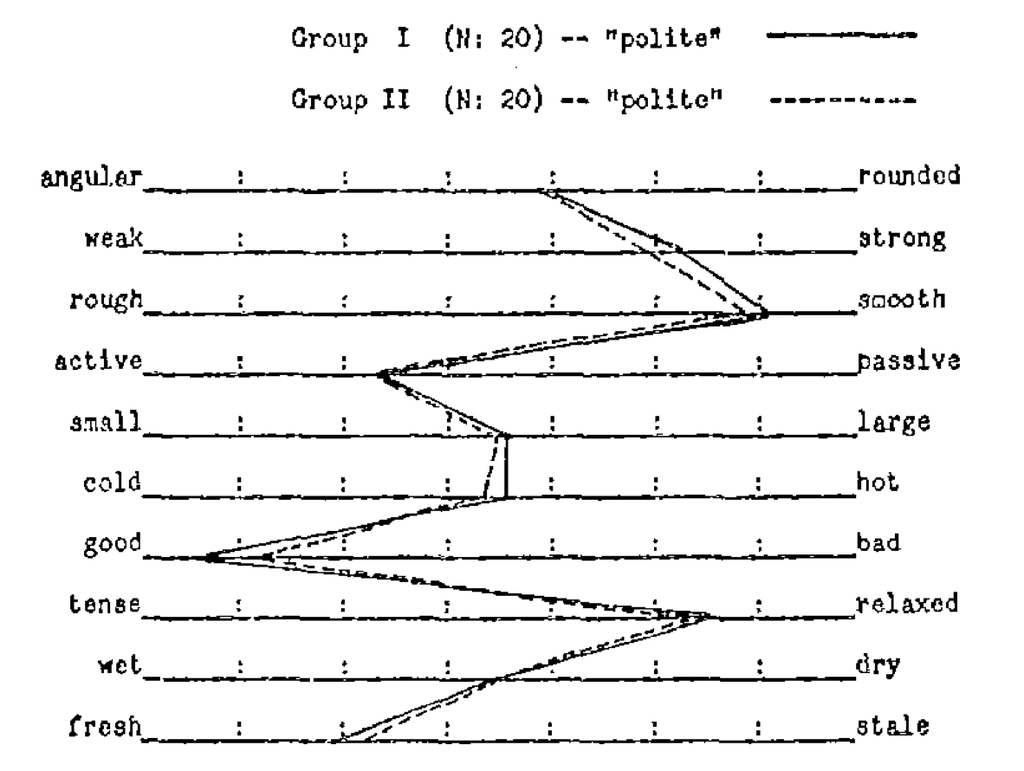

Semantic differentials, averaged across two groups of twenty study participants each. *Extracted from (Osgood 1952)*

### 3.2.2 Computational desiderata

Computers require numerical representations—but **how** should those numbers be structured?

**Symbolic / One-Hot Space**

- Words as arbitrary discrete IDs.
- **Purely structural:** Every word is perpendicular (orthogonal) to every other word.
- $\mathbf{v}_{\text{cat}} \cdot \mathbf{v}_{\text{dog}} = 0$
- Distance conveys **no semantic information**.

**Continuous Semantic Space**

- Words as coordinates in a shared space.
- **Semantically structured:** Spatial relationships encode linguistic properties.
- Geometric distance $\approx$ Semantic difference.

**The Goal:** Build a vector space where **geometry reflects semantics**.

## 3.3 Count-based semantic vectors

### 3.3.1 Key idea

**Word-word co-occurence matrix**: Use the *Distributional Hypothesis* to embed words in a *Semantic Space*.

1. Define a **vocabulary** $\mathcal{V}$ and a target word $w$.
2. Define a **context window** (e.g., $\pm 2$ or $\pm 5$ words around $w$).
3. Construct a **Term-Context Co-occurrence Matrix** $\mathbf{M} \in \mathbb{R}^{|\mathcal{V}| \times |\mathcal{V}|}$:
   - $\mathbf{M}_{ij} = \text{count of word } j \text{ appearing in the context window of word } i$.

$\to$ Each row of the matrix becomes a **distributional vector** representing its associate word in $|\mathcal{V}|$-dimensional space!

### 3.3.2 Example

- your eyes, `bildad`,” **cried** `peleg`, “thou
- ’st splice hands,” **cried** `peleg`, drawing nearer
- , hear him now,” **cried** `peleg` ,marching across
- the other part of the **ship**, captain `peleg` ripped
- “`bildad`,” **cried** captain `peleg`, ”
- “first congregational church,” **cried** `bildad`, “what
- do tell, now,” **cried** `bildad`, “is
- captain, and finally a **ship** owner; `bildad`,
- `bildad`, and get the **ship**’s papers.
- `keel`; but turning under **water**, swiftly shot to
- my conscience is in this **ship**’s `keel`.–
- her great `hull` through the **water**, as a horse
- whale lay rolling in the **water** like the capsized `hull`
- as the mark in a **ship**’s `hull`,
- in the pitchiest night the **ship**’s black `hull`
- the `hull` of a great **ship** new - laid upon
- nearing black `hull` of the **ship**; seemingly seeing in

**Target words**: `peleg`, `bildad`, `keel`, `hull`

**Context words**: `cried`, `water`, `ship`

|  | **cried** | **water** | **ship** |
| --- | --- | --- | --- |
| **peleg** |  |  |  |
| **bildad** |  |  |  |
| **keel** |  |  |  |
| **hull** |  |  |  |

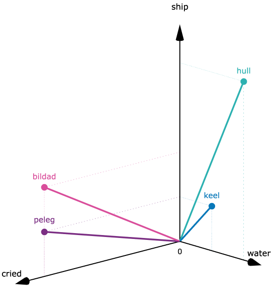

Vectors constructed form Moby Dick (Melville, 1851), context window size = 5.

**Caution**

Just an excerpt of what would be a much larger space ($|\mathcal{V}|-dimensional$)!

### 3.3.3 Other methods?

- Count models
  - Matrix models
    - word-word co-occurence
    - Latent Semantic Analysis (LSA)
    - GloVe
  - Random encoding models
    - Random indexing (RI)
- Prediction models
  - **word2vec**
  - fasttext

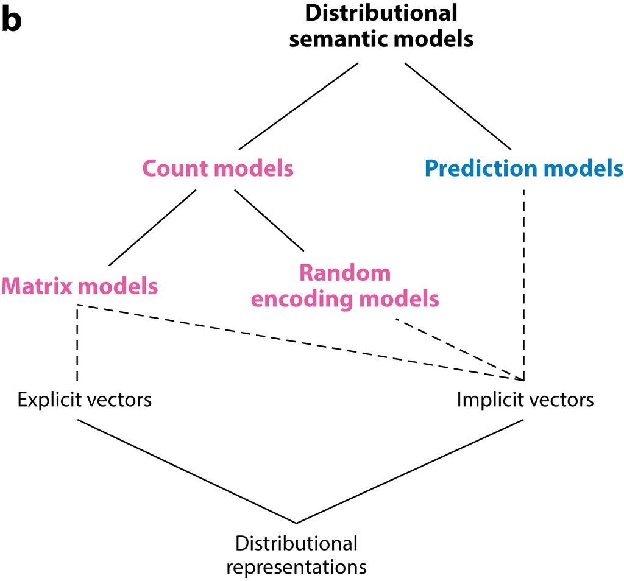

Taxonomy of distributional semantic models based on methods to build distributional vectors. *Extracted from (Lenci 2018).*

# 4 Geometry aside

## 4.1 Vector Arithmetic

### 4.1.1 Basics

- $\mathbf{a},\mathbf{b}\in\mathbb{R}^d$
- $a_i \in \mathbb{R}\ \forall i \in\{1,\cdots,d\}$
- $\mathbf{a} = \sum_{i=1}^d a_i \mathbf{\hat{e_i}}$
- Sum: $\mathbf{a}+\mathbf{b}=\sum_{i=1}^d (a_i+b_i) \mathbf{\hat{e_i}}$
- Inner dot product: $\mathbf{a} \cdot \mathbf{b} = \mathbf{a}^T \mathbf{b} = \sum_{i=1}^d a_i b_i$

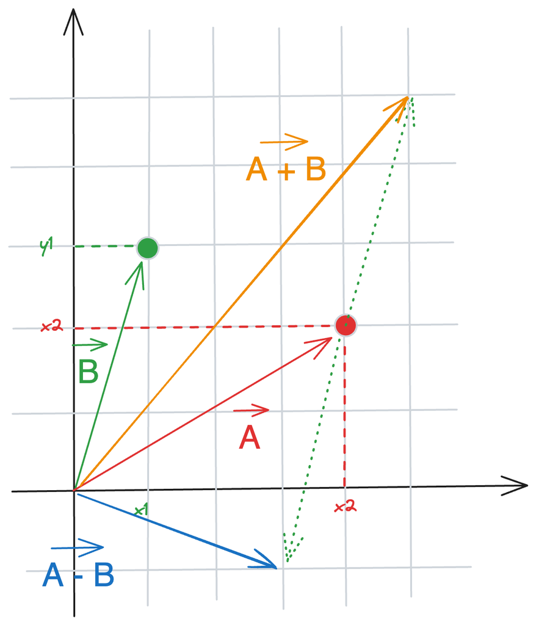

2D diagram

## 4.2 Notions of distances

### 4.2.1 Geometrical Distances in 2 dimensions

Different notions of distance, e.g.:

- **Euclidean**: $\sqrt{\left(x_1-y_1\right)^2+\left(x_2-y_2\right)^2}$
- **Manhattan** (L1): $\left|x_1-y_1\right|+\left|x_2-y_2\right|$
- **Cosine**: $1 - \cos\theta = 1 - \frac{x_1 y_1 + x_2 y_2}{\sqrt{x_1^2 + x_2^2} \, \sqrt{y_1^2 + y_2^2}}$
  - ⚠️ formally cosine distance is not a metric, but a dissimilarity measure

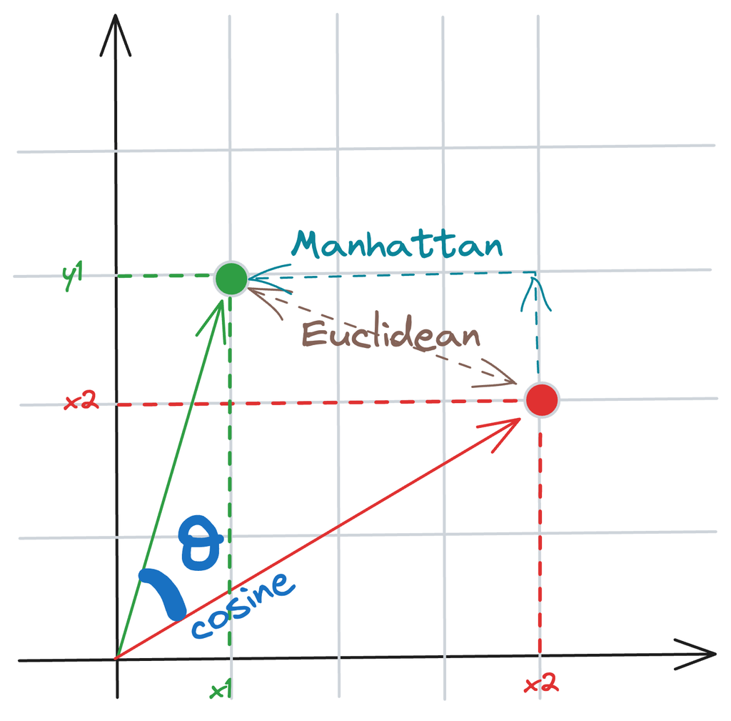

*2D diagram.*

### 4.2.2 Geometrical Distances in N dimensions

Different notions of distance, e.g.:

- **Euclidean**: $d(x,y)=\sqrt{\sum_{i=1}^N(x_i-y_i)^2}$
- **Manhattan** (L1): $d(x,y)=\sum_{i=1}^N|x_i-y_i|$
- **Cosine**: $1 - \cos\theta = 1 - \frac{\mathbf{x}\cdot\mathbf{y}}{\lVert\mathbf{x}\rVert\lVert\mathbf{y}\rVert}$
  - ⚠️ formally not a metric, but a dissimilarity measure

**Mathematical Formalization**

1. The distance between an object and itself is always zero.
2. The distance between distinct objects is always positive.
3. Distance is symmetric.
4. Distance satisfies the triangle inequality.

### 4.2.3 Beware of the curse!

**Curse of dimensionality *(coined by (Bellman 1966))* (see e.g.: (Domingos 2012))**

- **Sparsity:** data points occupy a tiny fraction of the space.
- **Distance collapse:** distances between points converge → “everything is equally far.”
- **Implication:** similarity measures lose discriminative power.

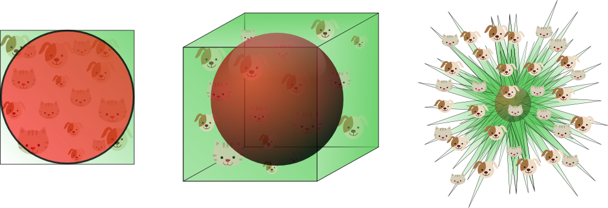

*Illustration of the curse of dimensionality: As dimensionality increases, a larger percentage of the data resides at the border of the feature space. Extracted from (Spruyt 2015).*

### 4.2.4 In practice: (most often) cosine similarity

Dot Product:
$$\mathbf{A}\cdot\mathbf{B} = ||\mathbf{A}||\ ||\mathbf{B}||\cos{\theta}$$

Cosine similarity:
$$\cos{\theta} = \frac{\mathbf{A}\cdot\mathbf{B}}{\lVert\mathbf{A}\rVert\ \lVert\mathbf{B}\rVert}$$

**Origins**

Use of cosine similarity for related tasks is inherited from Information Retrieval and Vector Space Models (Salton, Wong, and Yang 1975).

**No Free Lunch**

Mathematically also suffers from the curse of dimensionality, but **empirically** works better in practice (most often)…

… still has know limitations, e.g.:

- can sometimes yield arbitrary (and therefore meaningless) ‘similarities’ (Steck, Ekanadham, and Kallus 2024);
- relative to human judgements, cosine underestimates similarity of frequent words (Zhou et al. 2022).

## 4.3 Dimensionality Reduction

### 4.3.1 From high- to lower-dimensional spaces

Can serve different purposes:

- Mitigate curse of dimensionality
- Visualisation & Exploration
- Analytical

$\to$ Reminder (?): various methods exist (MDS, PCA, tSNE, UMAP, …)

### 4.3.2 Quick Cheatsheet

[interactive chart not shown]

For more information about UMAP, see [this blogpost](https://pair-code.github.io/understanding-umap/) and the mammoth example (Coenen and Pearce 2019).

# 5 Dense Representations: Word2Vec

## 5.1 Paradigm Shift: Count vs. Predict

### 5.1.1 Why Move Beyond Count Matrices?

Recall our count-based $M \in \mathbb{R}^{|\mathcal{V}| \times |\mathcal{V}|}$ co-occurrence matrix:

$\to$ Representations are long (~$10^5$) and sparse (mostly zeros),

we would like short (~$10^2$) and dense (mostly non zeros):

- more efficient computationally
- easier to use as features in ML (fewer weights to tune)
- may generalize better than explicit count
- may represent meaning better
- **simply work better in practice**

### 5.1.2 Prediction as Representation

Instead of **counting frequencies**, we play a continuous **guessing game**: *Is word $w_A$ likely to show near $w_B$?*

- **Train a classifier** on a **prediction** task
  - **self-supervised** training on a corpus, “gold labels” directly from the corpus
  - pretext task: we are not really interested in the actual predictions
- The (semantic vectors =) **embeddings** are the **learned weights**

**Goal**

Make each vector “know” about the contexts/environments of its associated word.

## 5.2 Word2Vec Algorithms

### 5.2.1 Two Complementary Approaches

Mikolov, Chen, et al. (2013) introduced two distinct model topologies:

**1- Skip-gram**

Given a **Center Word** ($c$), predict its surrounding **Context Words** ($o$).

```
        ┌──► Context (t-2)
        ├──► Context (t-1)
Center ─┼──► Context (t+1)
        └──► Context (t+2)
```

- **Strengths:** Works exceptionally well on smaller corpora; captures rare words effectively.

**2- Continuous Bag-of-Words (CBOW)**

Given surrounding **Context Words** ($o$), predict the missing **Center Word** ($c$).

```
Context (t-2) ──┐
Context (t-1) ──┼──► Center
Context (t+1) ──┤
Context (t+2) ──┘
```

- **Strengths:** Trains several times faster; slightly better accuracy for frequent words.

### 5.2.2 Skip-gram process

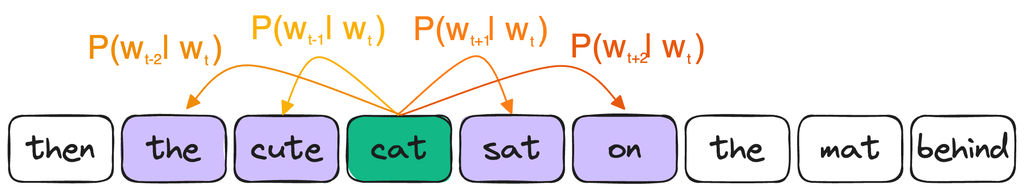

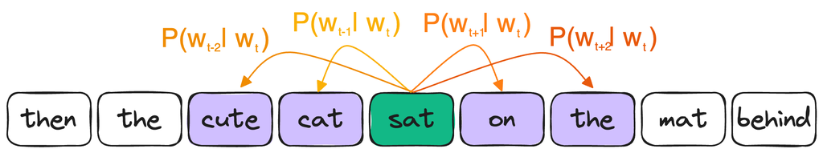

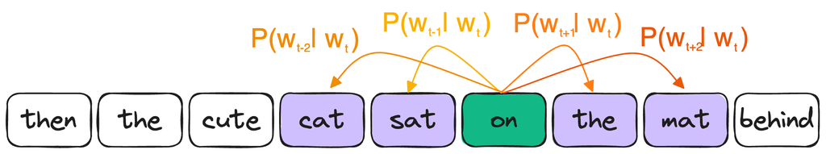

1. Take a huge text corpus;
2. Go over the text with a sliding window, moving one word at a time.
   - At each step, there is a central word and context words (other words in this window);
3. For the central word, compute probabilities of context words;
4. Adjust the vectors to increase these probabilities.

## 5.3 How to compute the probabilities?

### 5.3.1 Two Vectors Per Word

For every word $w$ in vocabulary $\mathcal{V}$, the model maintains **two separate $d$-dimensional vectors** (usually, $d$~$10^2$):

- $\mathbf{v}_w \in \mathbb{R}^d$ when $w$ is acting as a **Center word** ($c$ - central).
- $\mathbf{u}_w \in \mathbb{R}^d$ when $w$ is acting as a **Context word** ($o$ - outside).

$\theta=\left\{\{\mathbf{v}_w\}_{w\in\mathcal{V}},\{\mathbf{u}_w\}_{w\in\mathcal{V}}\right\}$ are the **parameters** of our model.

The **similarity** between center word $c$ and context word $o$ is modeled by their **inner dot product** ($\propto$ cosine similarity):

$$\mathbf{u}_o^\top \mathbf{v}_c$$

### 5.3.2 From similarity to probability

Use the **softmax** function:

$$P(o \mid c, \theta) = \frac{\exp(\mathbf{u}_o^\top \mathbf{v}_c)}{\sum_{w \in \mathcal{V}} \exp(\mathbf{u}_w^\top \mathbf{v}_c)}$$

- the exponential $\exp(-)$ makes every value positive
- the denominator sum ensures $P\in[0,1]$, and probabilities sum to $1$.

### 5.3.3 In practice: shallow neural network

- center vectors $\mathbf{v}_w$ rows of $\mathbf{W}\in\mathbb{R}^{|\mathcal{V}|\times d}$
- context vectors $\mathbf{u}_w$ columns of $\mathbf{W^\prime}\in\mathbb{R}^{d\times|\mathcal{V}|}$
1. Input: OHE $\mathbf{x}\in\mathbb{R}^{|\mathcal{V}|}$
2. $\mathbf{h} = \mathbf{x}\mathbf{W}\in\mathbb{R}^d$ (selects the row associated with the OHE)
3. $\mathbf{z} = \mathbf{h}\mathbf{W^\prime}\in\mathbb{R}^{|\mathcal{V}|}$ (logits: dot product from center to every word in vocabulary)
4. Apply softmax (get probabilities)

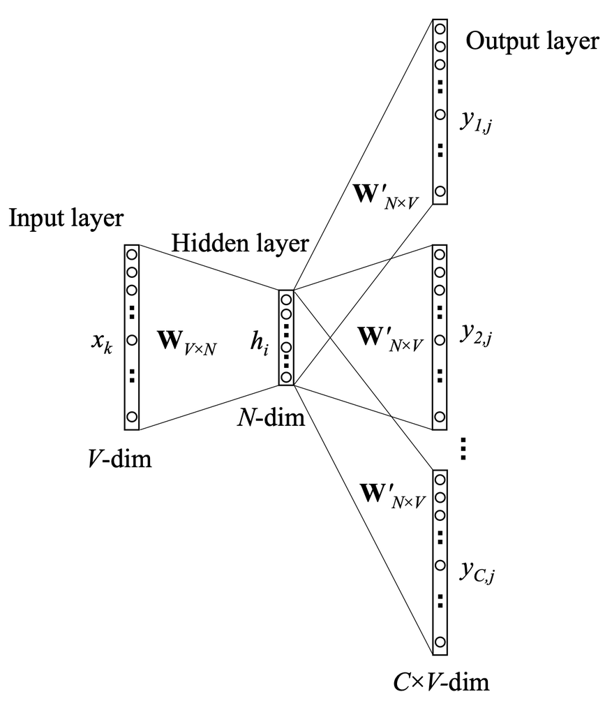

The skip-gram model. *Extracted from (Rong 2016).*

## 5.4 Training

### 5.4.1 Objective

The goal is to **maximise** the **likelihood** of our model $\theta$, given a corpus $\mathcal{C}$ for a specific window size $m$:

$$\begin{align}
L(\theta)&=\prod_{c=1}^{|\mathcal{C}|} P(w_{c-m},\cdots,w_{c+m} | w_c) \\
&\stackrel{ind.}{=} \prod_{c=1}^{|\mathcal{C}|} \prod_{-m\leq j\leq m, j\neq 0} P(w_{c+j} | w_c)
\end{align}$$

### 5.4.2 Loss Function

In practice, **minimize** the **negative log-likelihood**:

$$\begin{align}
J(\theta)&=-\frac{1}{|\mathcal{C}|}\log L(\theta) \\
&= -\frac{1}{|\mathcal{C}|}\log\left[\prod_{c=1}^{|\mathcal{C}|} \prod_{-m\leq j\leq m, j\neq 0} P(w_{c+j} | w_c)\right] \\
&= -\frac{1}{|\mathcal{C}|}\sum_{c=1}^{|\mathcal{C}|}\sum_{-m\leq j\leq m, j\neq 0} \log\left( P(w_{c+j}| w_c)\right) \\
\end{align}$$

$$\begin{align}
J(\theta)&=\frac{1}{|\mathcal{C}|}\sum_{c=1}^{|\mathcal{C}|}\sum_{-m\leq j\leq m, j\neq 0} J_{c,j}(\theta) \\
\end{align}$$

with:

$$J_{c,j}(\theta)=-\log\left(\frac{\exp(\mathbf{u}_{c+j}^\top \mathbf{v}_c)}{\sum_{w \in \mathcal{V}} \exp(\mathbf{u}_w^\top \mathbf{v}_c)}\right)=-\mathbf{u}_{c+j}^\top \mathbf{v}_c+\log\left(\sum_{w \in \mathcal{V}} \exp(\mathbf{u}_w^\top \mathbf{v}_c)\right)$$

### 5.4.3 Negative Sampling (SNGS)

**Computational Bottleneck**

Before: for each pair of a central word and its context word, we had to update all vectors for context words. This is highly inefficient: for each step, the time needed to make an update is proportional to the vocabulary size (usually, $|\mathcal{V}|> 10^5$).

Solution: **Negative Sampling** (Mikolov, Sutskever, et al. 2013) $\to$ sample only $K$ ‘negative examples’; and use $P_+=\sigma(x)$, $P_-=\sigma(-x)$, with $\sigma(x)=\frac{1}{1+e^{-x}}$.

The loss becomes:

$$J_{c,j}=-\log\left(\sigma(\mathbf{u}_{c+j}^\top \mathbf{v}_c)\right)+\sum_{w \in\left\{{w_i}_1\cdots {w_i}_K\right\}} \log\left(\sigma(-\mathbf{u}_w^\top \mathbf{v}_c)\right)$$

### 5.4.4 Gradient Descent

For word2vec, given learning rate $\eta$, at each step, the parameters are updated according to:

- $\mathbf{v}_c^{n+1} = \mathbf{v}_c^{n} - \eta \frac{\partial J_{c,j}(\theta)}{\partial v_c}$
- $\mathbf{u}_w^{n+1}=\mathbf{u}_w^{n} - \eta \frac{\partial J_{c,j}(\theta)}{\partial \mathbf{u}_w}\ \forall w\in\mathcal{V}$

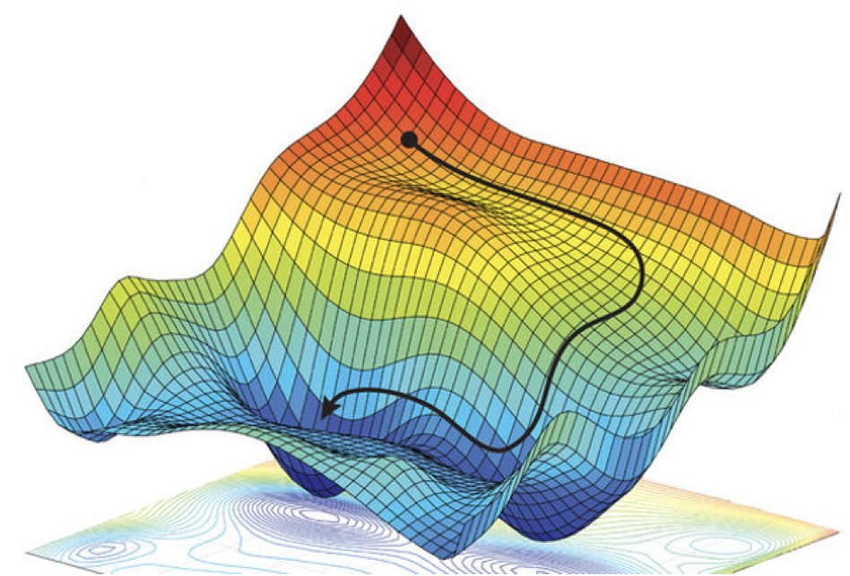

Gradient Descent Illustration. *Extracted from (Amini et al. 2019).*

# 6 Navigating Embedding Spaces

## 6.1 Embedding space structure

### 6.1.1 Training `word2vec` in practice

```python
from gensim.models import Word2Vec

# Load corpus, split sentences, tokenize,
# Define parameters, ...
# [ ... ]

model = Word2Vec( # instantiate & trains model
  sentences=sentences, # list[list] of tokenized sentences
  size=embedding_dimension, # size of the embeddings
  sg=1, # skipgram rather than cbow
  window=window_size, # size of the window
  epochs=n_epochs, # number of training passes
)
```

### 6.1.2 Global structures

```python
from gensim.models import Word2Vec
# [ ... ]
model = Word2Vec( # instantiate & trains model
  sentences=sentences, # list[list] of tokenized sentences
  size=embedding_dimension, # size of the embeddings
  sg=1, # skipgram rather than cbow
  window=window_size, # size of the window
  epochs=n_epochs, # number of training passes
)

vectors = model.wv[ # stores word vectors
  words # list of words (in vocabulary)
]
```

- Broad clusters by meaning, language, part-of-speech, etc.
- Global directions capturing abstract semantic attributes can be identified (cf. *analogies*)

t-SNE visualisation of custom Moby Dick `word2vec`:

[interactive chart not shown]

### 6.1.3 Local structures

```python
from gensim.models import Word2Vec
# [ ... ]
model = Word2Vec( # instantiate & trains model
  sentences=sentences, # list[list] of tokenized sentences
  size=embedding_dimension, # size of the embeddings
  sg=1, # skipgram rather than cbow
  window=window_size, # size of the window
  epochs=n_epochs, # number of training passes
)

vectors = model.wv.most_similar( # cosine similarity
  word, # word of interest (in vocab)
  topn=n_similar, # number of similar words to retrieve
)
```

- **smaller** context windows (e.g., $\pm2$) $\Rightarrow$ nearest words are **syntactically** similar words in same taxonomy
- **larger** context windows (e.g., $\pm5$) $\Rightarrow$ nearest words are related words in same **semantic** field

Example using `gensim`’s pre-trained `'word2vec-google-news-300'`:

- `croque_monsieur`’s neirest neighbours:

```
[('Croque_Monsieur', 0.7393720746040344),
 ('tartine', 0.7330116033554077),
 ('croque_madame', 0.7286978363990784),
 ('quiche_Lorraine', 0.7177014946937561),
 ('Coq_au_Vin', 0.7110365629196167),
 ('jambon', 0.7013630867004395),
 ('moules', 0.7013481855392456),
 ('Cassoulet', 0.6983660459518433),
 ('eggs_benedict', 0.6976872682571411),
 ('boeuf_bourguignon', 0.6962353587150574)]
```

Example using custom `word2vec` trained on *Moby Dick*:

- `ahab`’s neirest neighbours:

```
[('vehemently', 0.5342268347740173),
 ('mutter', 0.5329338312149048),
 ('headway', 0.529466986656189),
 ('inaccessible', 0.5006495714187622),
 ('respecting', 0.5005402565002441),
 ('parsee', 0.49932175874710083),
 ('foreboding', 0.4877033829689026),
 ('laughs', 0.48322594165802),
 ('pacing', 0.4829474985599518),
 ('unfaltering', 0.4828788638114929)]
```

## 6.2 Analogies

### 6.2.1 The parallelogram model

**Parallelogram** model of analogical reasoning (Rumelhart and Abrahamson 1973):

`man` is to `king` as `woman` is to `queen`

`A` is to `B` as `C` is to `D`

`A` : `B` :: `C` : `D`

`A` : `B` :: `C` : `??`

`??` = `B` - `A` + `C`

`king` - `man` + `woman` = `??`

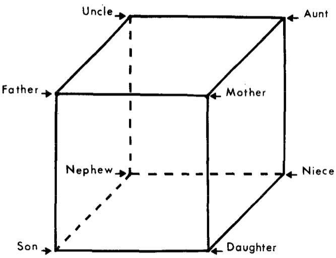

*Three-dimensional representation of relations among eight kinship terms. Extracted from (Rumelhart and Abrahamson 1973).*

### 6.2.2 Analogies & Vector arithmetic

```python
vectors = model.wv.most_similar( # cosine similarity
  positive=["B", "C"], # "+" words
  negative=["A"], # "-" words
  topn=n_similar, # number of similar words to retrieve
)
```

Some examples (using `gensim`’s pre-trained `'word2vec-google-news-300'`):

- `king` $-$ `man` $+$ `woman` $\approx$ `queen` ($\to$ top 3: (`'queen'`, 0.71), (`'monarch'`, 0.62), (`'princess'`, 0.59))
- `france` $-$ `paris` $+$ `berlin` $\approx$ `germany` ($\to$ top 3: (`'germany'`, 0.51) (`'european'`, 0.49) (`'german'`, 0.47))

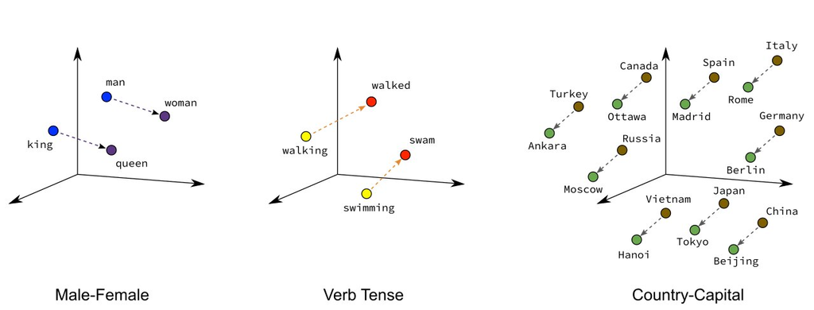

Toy illustration of word-vector relationships. [source](https://web.engr.oregonstate.edu/~huanlian/teaching/ML/2024fall/unit4/word_embeddings.html)

- `croque_monsieur` $-$ `france` $+$ `germany` $\approx$ `Wiener_schnitzel` ($\to$ top 3: (`'Wiener_schnitzel'`, 0.57) (`'pork_schnitzel'`, 0.56) (`'veal_parmigiana'`, 0.56))

## 6.3 Embeddings as a window onto the world

### 6.3.1 Bias and cultural stereotypes

*“Man is to computer programmer as woman is to homemaker?”* Bolukbasi et al. (2016)

- `computer_programmer` $-$ `man` $+$ `woman` $\approx$ `homemaker` ($\to$ top 3: (`'homemaker'`, 0.56) (`'housewife'`, 0.51) (`'graphic_designer'`, 0.51))
- `doctor` $-$ `father` $+$ `mother` $\approx$ `nurse` ($\to$ top 3: (`'nurse'`, 0.71) (`'doctors'`, 0.66) (`'gynecologist'`, 0.65))

### 6.3.2 Bias and cultural stereotypes, over time

*“Word embeddings quantify 100 years of gender and ethnic stereotypes”* (Garg et al. 2018)

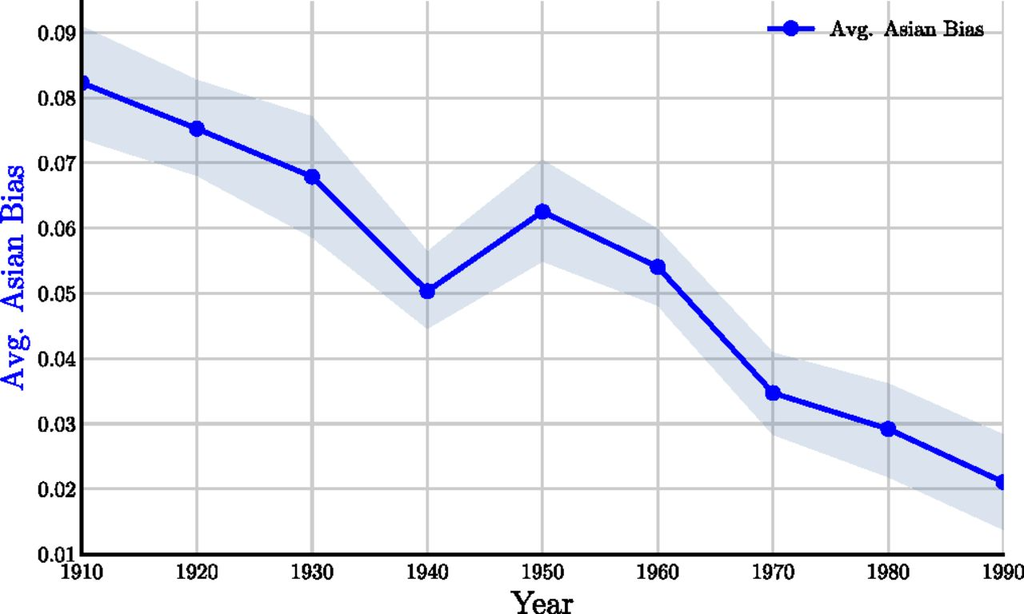

Asian bias score over time related to dehumanizing adjectives (e.g., *bizarre*, *greedy*, *monstruous*, …) in COHA data.

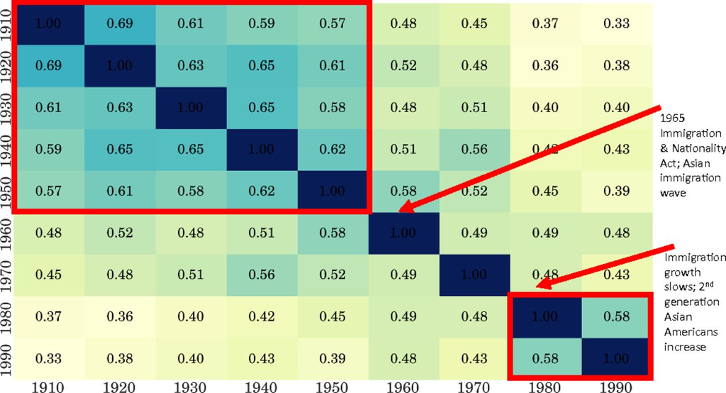

Pearson correlation in embedding Asian bias scores for adjectives over time between embeddings for each decade.

## 6.4 Semantic Shifts

### 6.4.1 How to study semantic shifts using `word2vec`?

[figure not shown]

[figure not shown]

*Los Angeles Time. May 2nd 1992*

$\to$ Today’s [Hands-on Exercise](https://github.com/d-noe/NLP_DH_F26/tree/main/code/2_word_representation): **Semantic Shift Analysis through `word2vec` representations**, based on (Pedrazzini and McGillivray 2022) ([Living With Machines project](https://livingwithmachines.ac.uk)).

### 6.4.2 Aligning embedding spaces…

**Geometry vs. Coordinates**

`word2vec` relies on *stochastic optimisation* to map words into space. The algorithm **optimises a *geometry*** (relationships between word-vectors), **not a *coordinate system***.

In other words, two `word2vec` models trained independently (even on the same corpus) cannot be directly compared!

**Orthogonal Procrustes transform**

Align embedding spaces through rotation: for $\mathbf{X},\mathbf{Y}\in\mathbb{R}^{|\mathcal{V}|\times d}$ resp. the target and reference representations, find the orthogonal matrix $\mathbf{W}\in\mathbb{R}^{d\times d}$ that minimizes:
$$\lVert XW - Y \rVert_{F}$$

The closed-form solution exists and can be computed efficiently using singular value decomposition (SVD).

### 6.4.3 Aligning embedding spaces… for diachronic analyses

*“HistWords: Word Embeddings for Historical Text”* (Hamilton, Leskovec, and Jurafsky 2016)

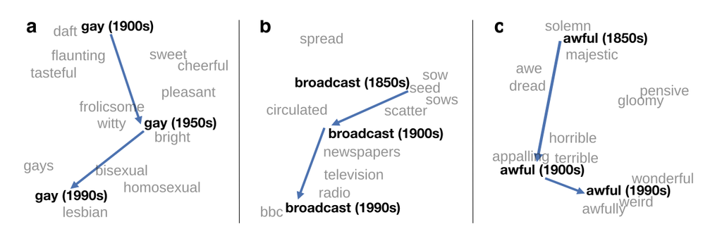

2D visualisation of semantic change in English based on word2vec embeddings trained on “six large historical datasets”. *Extracted from (Hamilton, Leskovec, and Jurafsky 2016).*

**Simpler is better?**

Gonen et al. (2020) propose a simpler approach: focusing on *words’ local neighborhoods* (instead of alignment).

They claim that their method is simpler, more interpretable, and more stable.

### 6.4.4 Aligning embedding spaces… for translation

Aligning embedding spaces from different languages to find correspondances across languages (Conneau et al. 2018).

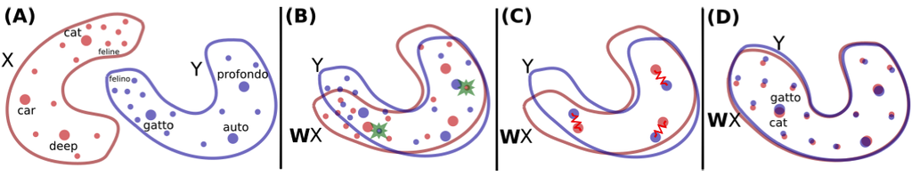

Toy illustration of the alignment strategy between embedding spaces of different languages. *Extracted from (Conneau et al. 2018)*

# 7 Conclusion

- Tokenization: `raw text` $\to$ `discrete units` (& Vocabulary mapping)
- Long, sparse representations: OHE & word-word co-occurence
- Distributed, short, dense representations (learned with `word2vec`)
  - Explorable semantic spaces that encode the knowledge & biases of the training corpus

## References

Amini, Alexander, Ava Soleimany, Sertac Karaman, and Daniela Rus. 2019. “Spatial Uncertainty Sampling for End-to-End Control.” https://arxiv.org/abs/1805.04829.

Bellman, Richard. 1966. “Dynamic Programming.” *Science* 153 (3731): 34–37.

Bolukbasi, Tolga, Kai-Wei Chang, James Zou, Venkatesh Saligrama, and Adam Kalai. 2016. “Man Is to Computer Programmer as Woman Is to Homemaker? Debiasing Word Embeddings.” In *Proceedings of the 30th International Conference on Neural Information Processing Systems*, 4356–64. NIPS’16. Red Hook, NY, USA: Curran Associates Inc.

Coenen, Andy, and Adam Pearce. 2019. “Understanding Umap.” *PAIR Page Redirection*. https://pair-code.github.io/understanding-umap/.

Conneau, Alexis, Guillaume Lample, Marc’Aurelio Ranzato, Ludovic Denoyer, and Hervé Jégou. 2018. “Word Translation Without Parallel Data.” https://arxiv.org/abs/1710.04087.

Domingos, Pedro. 2012. “A Few Useful Things to Know about Machine Learning.” *Communications of the ACM* 55 (10): 78–87. https://dl.acm.org/doi/abs/10.1145/2347736.2347755?fbclid=IwAR0ribQrR3TwrKb0rOWW6gsvE1CuoxIfcPizvw_ReENZoQMJ229o5Ar2uAs.

Firth, John. 1957. “A Synopsis of Linguistic Theory, 1930-1955.” *Studies in Linguistic Analysis*, 10–32.

Gage, Philip. 1994. “A New Algorithm for Data Compression.” *C Users Journal* 12 (2): 23–38.

Garg, Nikhil, Londa Schiebinger, Dan Jurafsky, and James Zou. 2018. “Word Embeddings Quantify 100 Years of Gender and Ethnic Stereotypes.” *Proceedings of the National Academy of Sciences* 115 (16). https://doi.org/10.1073/pnas.1720347115.

Gonen, Hila, Ganesh Jawahar, Djamé Seddah, and Yoav Goldberg. 2020. “Simple, Interpretable and Stable Method for Detecting Words with Usage Change Across Corpora.” In *Proceedings of the 58th Annual Meeting of the Association for Computational Linguistics*, edited by Dan Jurafsky, Joyce Chai, Natalie Schluter, and Joel Tetreault, 538–55. Online: Association for Computational Linguistics. https://doi.org/10.18653/v1/2020.acl-main.51.

Hamilton, William L., Jure Leskovec, and Dan Jurafsky. 2016. “Diachronic Word Embeddings Reveal Statistical Laws of Semantic Change.” In *Proceedings of the 54th Annual Meeting of the Association for Computational Linguistics (Volume 1: Long Papers)*, edited by Katrin Erk and Noah A. Smith, 1489–1501. Berlin, Germany: Association for Computational Linguistics. https://doi.org/10.18653/v1/P16-1141.

Harris, Zellig S. 1954. “Distributional Structure.” *Word* 10 (2-3): 146–62.

Jurafsky, Daniel, and James H. Martin. 2026. *Speech and Language Processing: An Introduction to Natural Language Processing, Computational Linguistics, and Speech Recognition, with Language Models*. 3rd ed. https://web.stanford.edu/~jurafsky/slp3/.

Lenci, Alessandro. 2018. “Distributional Models of Word Meaning.” *Annual Review of Linguistics* 4: 151–71.

Mikolov, Tomas, Kai Chen, Greg Corrado, and Jeffrey Dean. 2013. “Efficient Estimation of Word Representations in Vector Space.” https://arxiv.org/abs/1301.3781.

Mikolov, Tomas, Ilya Sutskever, Kai Chen, Greg Corrado, and Jeffrey Dean. 2013. “Distributed Representations of Words and Phrases and Their Compositionality.” https://arxiv.org/abs/1310.4546.

Mikolov, Tomas, Wen-tau Yih, and Geoffrey Zweig. 2013. “Linguistic Regularities in Continuous Space Word Representations.” In *Proceedings of the 2013 Conference of the North American Chapter of the Association for Computational Linguistics: Human Language Technologies*, edited by Lucy Vanderwende, Hal Daumé III, and Katrin Kirchhoff, 746–51. Atlanta, Georgia: Association for Computational Linguistics. https://aclanthology.org/N13-1090/.

Osgood, Charles E. 1952. “The Nature and Measurement of Meaning.” *Psychological Bulletin* 49 (3): 197.

Pedrazzini, Nilo, and Barbara McGillivray. 2022. “Machines in the Media: Semantic Change in the Lexicon of Mechanization in 19th-Century British Newspapers.” In *Proceedings of the 2nd International Workshop on Natural Language Processing for Digital Humanities*, edited by Mika Hämäläinen, Khalid Alnajjar, Niko Partanen, and Jack Rueter, 85–95. Taipei, Taiwan: Association for Computational Linguistics. https://doi.org/10.18653/v1/2022.nlp4dh-1.12.

Rong, Xin. 2016. “Word2vec Parameter Learning Explained.” https://arxiv.org/abs/1411.2738.

Rumelhart, David E, and Adele A Abrahamson. 1973. “A Model for Analogical Reasoning.” *Cognitive Psychology* 5 (1): 1–28.

Salton, G., A. Wong, and C. S. Yang. 1975. “A Vector Space Model for Automatic Indexing.” *Commun. ACM* 18 (11): 613–20. https://doi.org/10.1145/361219.361220.

Sennrich, Rico, Barry Haddow, and Alexandra Birch. 2016. “Neural Machine Translation of Rare Words with Subword Units.” In *Proceedings of the 54th Annual Meeting of the Association for Computational Linguistics (Volume 1: Long Papers)*, 1715–25.

Spruyt, Vincent. 2015. “The Curse of Dimensionality in Classification.” *Computer Vision for Dummies*. https://www.visiondummy.com/2014/04/curse-dimensionality-affect-classification/.

Steck, Harald, Chaitanya Ekanadham, and Nathan Kallus. 2024. “Is Cosine-Similarity of Embeddings Really about Similarity?” In *Companion Proceedings of the ACM Web Conference 2024*, 887–90. WWW ’24. New York, NY, USA: Association for Computing Machinery. https://doi.org/10.1145/3589335.3651526.

Wittgenstein, Ludwig. 1953. *Philosophical Investigations. Wittgenstein*. Macmillan.

Zhou, Kaitlyn, Kawin Ethayarajh, Dallas Card, and Dan Jurafsky. 2022. “Problems with Cosine as a Measure of Embedding Similarity for High Frequency Words.” https://arxiv.org/abs/2205.05092.

Word Representation

[figure not shown]